# Computer Vision Project

Part-A  
DOMAIN: Botanical Research  
CONTEXT: University X is currently undergoing some research involving understanding the characteristics of plant and plant seedlings at various stages of growth. They already have have invested on curating sample images. They require an automation which can create a classifier capable of determining a plant's species from a photo.

1. Import and Understand the data  
   A. Extract ‘plant-seedlings-classification.zip’ into new folder (unzipped) using python.  
   B. Map the images from train folder with train labels to form a DataFrame.  
   C. Write a function that will select n random images and display images along with its species.

```python
import numpy as np
import pandas as pd
import matplotlib.pyplot as plt
import seaborn as sns
import scipy.stats as stats
import math
from sklearn.model_selection import train_test_split
%matplotlib inline
import warnings
warnings.filterwarnings('ignore')
import tensorflow as tf
from tensorflow.keras.utils import to_categorical
from tensorflow.keras import losses
from tensorflow.keras import optimizers
from tensorflow.keras import Sequential
from tensorflow.keras.layers import Dense
from sklearn.model_selection import train_test_split
from sklearn import preprocessing
from tensorflow.keras.models import Sequential
from tensorflow.keras.layers import Dense, Dropout, BatchNormalization
from sklearn.metrics import accuracy_score, confusion_matrix, precision_score, recall_score, f1_score, precision_recall_curve, auc
from tensorflow.keras import optimizers, metrics
import os
import cv2
```

```python
from zipfile import ZipFile
```

```python
#1A)Extract the files
zip = ZipFile('plant-seedlings-classification.zip')
zip.extractall()
```

```python
#1A)Extract the files
dataset = 'C:\\Users\\rat_monster\\Great learning\\Untitled Folder\\plant-seedlings-classification\\train'
X = []
y = []
labels = []

# list all folders inside train directory
for i in os.listdir(dataset):
    print(i)
    if i!= '.DS_Store':
      labels.append(i)
      for j in os.listdir(os.path.join(dataset, i)):
        # read each image inside train directory one by one
        dummy = cv2.imread(os.path.join(dataset, i, j))

        X.append(dummy)
        y.append(i)
```

```
.DS_Store
Black-grass
Charlock
Cleavers
Common Chickweed
Common wheat
Fat Hen
Loose Silky-bent
Maize
Scentless Mayweed
Shepherds Purse
Small-flowered Cranesbill
Sugar beet
```

```python
dataset = 'C:\\Users\\rat_monster\\Great learning\\Untitled Folder\\plant-seedlings-classification\\train'
```

```python
#1B)Making dataframe with name of image, image and type(label)
data={'Name':[],'Image':[],'Type':[]}


# list all folders inside train directory
for i in os.listdir(dataset):

    if i!= '.DS_Store':
        for j in os.listdir(os.path.join(dataset, i)):

            data['Name'].append(j)
            dummy=cv2.imread(os.path.join(dataset, i, j))
            dummy = cv2.resize(dummy, (128, 128)) #resizing all images to 128 by 128 format
            data['Image'].append(dummy)


            data['Type'].append(i)
```

```python
#1B)Making dataframe with name of image, image and type(label)
dataframe=pd.DataFrame(data)
```

```python
dataframe.head()
```

|  | Name | Image | Type |
| --- | --- | --- | --- |
| 0 | 0050f38b3.png | [[[24, 47, 77], [33, 54, 81], [45, 66, 89], [5... | Black-grass |
| 1 | 0183fdf68.png | [[[42, 48, 56], [50, 56, 66], [51, 55, 69], [5... | Black-grass |
| 2 | 0260cffa8.png | [[[22, 29, 49], [28, 36, 52], [22, 33, 51], [3... | Black-grass |
| 3 | 05eedce4d.png | [[[51, 84, 108], [55, 88, 111], [54, 88, 110],... | Black-grass |
| 4 | 075d004bc.png | [[[167, 164, 164], [168, 168, 165], [162, 160,... | Black-grass |

```python
import random
```

```python
#1C) Function the display the n random images
def show_image(*args):
    n=int(input('Number of images to be displayed:'))
    l1=random.sample(range(0, len(dataframe)), n)
    for i in l1:
        plt.imshow(dataframe['Image'][i],aspect='auto')
        plt.show()
        print(dataframe['Image'][i].shape)
        print(dataframe['Type'][i])
```

```
Number of images to be displayed:3
```

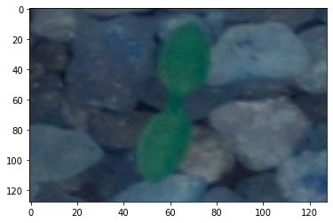

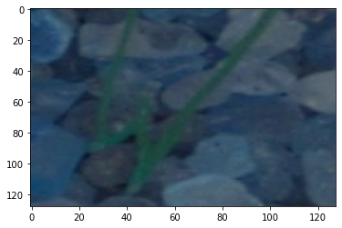

```
(128, 128, 3)
Common Chickweed
(128, 128, 3)
Loose Silky-bent
```

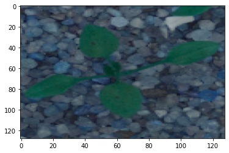

```
(128, 128, 3)
Common Chickweed
```

```python
show_image()
```

1. Data preprocessing  
   A. Create X & Y from the DataFrame.  
   B. Encode labels of the images.  
   C. Unify shape of all the images.  
   D. Normalise all the images.

```python
#dropping the image name from dataframe as it is not necessary
dataframe1=dataframe.drop(['Name'],axis=1)
```

```python
#2A) create X and Y
X=dataframe1.iloc[:,:-1]

Y=dataframe1.iloc[:,-1]
```

```python
#2B) encoding the labels of all images
from sklearn.preprocessing import LabelEncoder
label_encoder = LabelEncoder()
Y_encod = label_encoder.fit_transform(Y)
Y_label= tf.keras.utils.to_categorical(Y_encod)
```

```python
#2C) Unify shape of all images
#2C) All images are transformed to 128X128X3 format while loading the data
#Converting the dataframe to array format for CNN of input data
image_data = np.array(X['Image'].values.tolist())
```

```python
#2D) Normalize image data
image_data=image_data/256
```

1. Model training

A. Split the data into train and test data.  
B. Create new CNN architecture to train the model.  
C. Train the model on train data and validate on test data.  
D. Select a random image and print actual label and predicted label for the same.

```python
#3A) Split the data to train and test data
from sklearn.model_selection import train_test_split
x_train, x_test, y_train, y_test = train_test_split(image_data, Y_label, test_size=0.3, random_state=12)
```

```python
#3B)CNN architecture
from tensorflow.keras.models import Sequential
from tensorflow.keras.layers import Convolution2D, Dropout, Dense, Flatten, BatchNormalization, MaxPooling2D


model_1 = Sequential()

model_1.add(BatchNormalization(input_shape = (128, 128, 3)))

model_1.add(Convolution2D(filters = 32, kernel_size = 3, activation ='relu', input_shape = (128, 128, 3)))
model_1.add(MaxPooling2D(pool_size = 2))


model_1.add(Convolution2D(filters = 64, kernel_size = 3, padding = 'same', activation = 'relu'))
model_1.add(MaxPooling2D(pool_size = 2))

model_1.add(Flatten())

model_1.add(Dense(units = 64,activation = 'relu'))


model_1.add(Dense(units = 12, activation = 'softmax'))
```

```python
from tensorflow.keras.optimizers import Adam
optimizer = Adam()
model_1.compile(optimizer='adam', loss = 'categorical_crossentropy', metrics = ['accuracy'])
model_1.summary()
```

```
Model: "sequential"
_________________________________________________________________
 Layer (type)                Output Shape              Param #
=================================================================
 batch_normalization (BatchN  (None, 128, 128, 3)      12
 ormalization)

 conv2d (Conv2D)             (None, 126, 126, 32)      896

 max_pooling2d (MaxPooling2D  (None, 63, 63, 32)       0
 )

 conv2d_1 (Conv2D)           (None, 63, 63, 64)        18496

 max_pooling2d_1 (MaxPooling  (None, 31, 31, 64)       0
 2D)

 flatten (Flatten)           (None, 61504)             0

 dense (Dense)               (None, 64)                3936320

 dense_1 (Dense)             (None, 12)                780

=================================================================
Total params: 3,956,504
Trainable params: 3,956,498
Non-trainable params: 6
_________________________________________________________________
```

```python
MODEL1=model_1.fit(x_train, y_train, epochs = 15, validation_data = (x_test, y_test), initial_epoch=0)
```

```python
#3C)Evaluation on test data
cnn_loss, cnn_accuracy = model_1.evaluate(x_test, y_test, verbose=1)
print('Test accuracy:', cnn_accuracy)
```

```
Test accuracy: 0.7185965180397034
```

```python
predict=model_1.predict(x_test)
```

```python
y_pred_final=[]
for i in predict:
  y_pred_final.append(np.argmax(i))
```

```python
y_test_1=[]
for i in y_test:
  y_test_1.append(np.argmax(i))
```

```python
#3D) Predict on random image
ran=random.sample(range(0,image_data.shape[0]),1)
image=image_data[ran]/255
image=np.reshape(image,(1,128,128,3))
predict1=model_1.predict(image)
print('predicted label is',np.argmax(predict1))
print('Actual label is',np.argmax(Y_label[ran]))
```

```
predicted label is 3
Actual label is 11
```

Part-B  
• DOMAIN: Botanical Research  
• CONTEXT: University X is currently undergoing some research involving understanding the characteristics of flowers. They already have invested on curating sample images. They require an automation which can create a classifier capable of determining a flower’s species from a photo.

1. Import and Understand the data  
   A. Import and read oxflower17 dataset from tflearn and split into X and Y while loading.  
   B. Print Number of images and shape of the images.  
   C. Print count of each class from y.

```python
#1A) Import the oxflower dataset
from tflearn.datasets import oxflower17
```

[output not shown]

```python
#1A)import data x and y
x, y = oxflower17.load_data()
```

```python
#1B) Number of imagees and shape
print('Number of images are',len(x))
print('shape of images is',x.shape)
```

```
Number of images are 1360
shape of images is (1360, 224, 224, 3)
```

```python
#1C)Count each label of y
np.unique(y, return_counts=True)
```

```
(array([ 0,  1,  2,  3,  4,  5,  6,  7,  8,  9, 10, 11, 12, 13, 14, 15, 16]),
 array([80, 80, 80, 80, 80, 80, 80, 80, 80, 80, 80, 80, 80, 80, 80, 80, 80],
       dtype=int64))
```

1. Image Exploration & Transformation  
   A. Display 5 random images.  
   B. Select any image from the dataset and assign it to a variable.  
   C. Transform the image into grayscale format and display the same.  
   D. Apply a filter to sharpen the image and display the image before and after sharpening.  
   E. Apply a filter to blur the image and display the image before and after blur.  
   F. Display all the 4 images from above questions besides each other to observe the difference.

```python
#2A)display 5 random images
def show_image1(*args):
    l1=random.sample(range(0,x.shape[0]),5)
    for i in l1:
        plt.imshow(x[i],aspect='auto')
        plt.show()
        print(y[i])
```

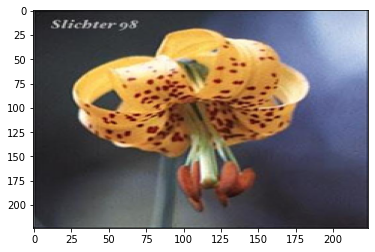

```
13
```

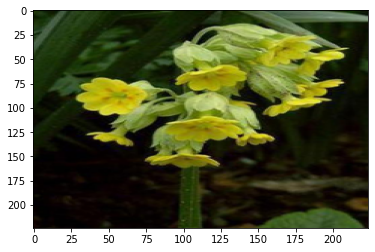

```
5
```

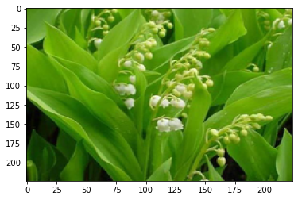

```
9
```

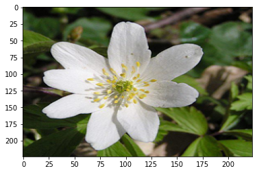

```
7
```

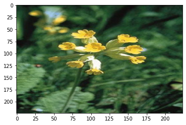

```
5
```

```python
#2A)display 5 random images
show_image1()
```

```python
#2B)Select an image
image=x[0]
```

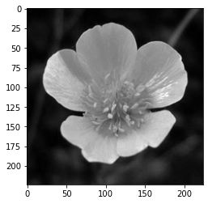

```python
#2B)change format to grayscale
gray = cv2.cvtColor(image, cv2.COLOR_BGR2GRAY)
plt.imshow(gray, cmap='gray')
```

```
Clipping input data to the valid range for imshow with RGB data ([0..1] for floats or [0..255] for integers).
```

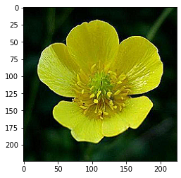

```python
#2C)Sharpen the image
kernel = np.array([[0, -1, 0],
                   [-1, 5,-1],
                   [0, -1, 0]])
sharp = cv2.filter2D(src=image, ddepth=-1, kernel=kernel)
plt.imshow(sharp)
```

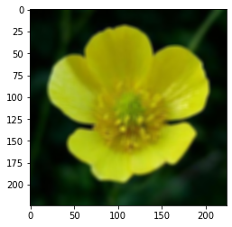

```python
#2D)Blur the image
blur = cv2.blur(image,(5,5))
plt.imshow(blur)
```

```
Clipping input data to the valid range for imshow with RGB data ([0..1] for floats or [0..255] for integers).
```

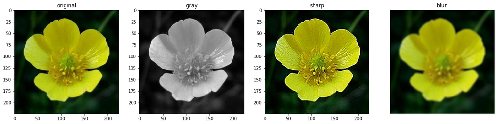

```python
#2E)Display above images at one place
plt.figure(figsize=(20, 20))
plt.subplot(1, 4,1)
plt.title('original')
plt.imshow(image)
plt.subplot(1, 4,2)
plt.title('gray')
plt.imshow(gray, cmap='gray')
plt.subplot(1, 4,3)
plt.title('sharp')
plt.imshow(sharp)
plt.subplot(1, 4,4)
plt.title('blur')
plt.imshow(blur)

plt.axis('off')
plt.show()
```

1. Model training and Tuning:  
   A. Split the data into train and test with 80:20 proportion.  
   B. Train a model using any Supervised Learning algorithm and share performance metrics on test data.  
   C. Train a model using Neural Network and share performance metrics on test data.  
   D. Train a model using a basic CNN and share performance metrics on test data.  
   E. Predict the class/label of image ‘Prediction.jpg’ using best performing model and share predicted label.

```python
#3A) split the data in train and test
x_train, x_test, y_train, y_test = train_test_split(x, y, test_size=0.2, random_state=12)
```

```python
#reshaping the features for supervised learning and ANN
X_train_res = x_train.reshape((x_train.shape[0], -1))
X_test_res = x_test.reshape((x_test.shape[0], -1))
```

```python
#Normalizing the data
X_train_res=X_train_res/255
X_test_res=X_test_res/255
x_train=x_train/255
x_test=x_test/255
```

```python
#Conversion of target variable to dummy encoding for ANN and CNN
y_train_enc= tf.keras.utils.to_categorical(y_train)
y_test_enc = tf.keras.utils.to_categorical(y_test)
```

```python
#3B)Train the data on random forest classifier
from sklearn.ensemble import RandomForestClassifier
from sklearn.metrics import accuracy_score

model_RF = RandomForestClassifier(n_estimators=20,
                                    criterion='gini',
                                    max_depth=5)
model_RF.fit(X_train_res, y_train)


pred_RF = model_RF.predict(X_test_res)
RF_Test = accuracy_score(y_test, pred_RF)
print("Test Accuracy:",RF_Test)
```

```
Test Accuracy: 0.35294117647058826
```

```python
#3B)classification report on random forest classifier
from sklearn.metrics import classification_report
print(classification_report(y_test,pred_RF))
```

```
              precision    recall  f1-score   support

           0       0.54      0.41      0.47        17
           1       0.40      0.09      0.15        22
           2       0.55      0.85      0.67        13
           3       0.33      0.18      0.23        17
           4       0.29      0.82      0.43        11
           5       0.12      0.20      0.15        10
           6       0.36      0.24      0.29        17
           7       0.46      0.40      0.43        15
           8       0.42      0.67      0.52        12
           9       0.21      0.17      0.19        18
          10       0.14      0.20      0.17        15
          11       0.33      0.50      0.40        18
          12       0.33      0.56      0.42        18
          13       0.25      0.20      0.22        15
          14       0.17      0.06      0.09        17
          15       0.33      0.19      0.24        21
          16       0.92      0.69      0.79        16

    accuracy                           0.35       272
   macro avg       0.36      0.38      0.34       272
weighted avg       0.37      0.35      0.33       272
```

```python
#3C) Train the data on NN models
from tensorflow.keras.models import Sequential
from tensorflow.keras.layers import Activation, Dense
from tensorflow.keras import optimizers
from tensorflow.keras.layers import BatchNormalization, Dropout
```

```python
#3C) creating a NN model
model2 = Sequential()
model2.add(Dense(128, input_shape = (150528, ),kernel_initializer='he_normal')) #total no of inputs=224X224X3
model2.add(Activation('sigmoid'))
model2.add(BatchNormalization())
model2.add(Dropout(0.5))
model2.add(Dense(256))
model2.add(Activation('sigmoid'))
model2.add(BatchNormalization())
model2.add(Dropout(0.5))
model2.add(Dense(256))
model2.add(Activation('sigmoid'))
model2.add(BatchNormalization())
model2.add(Dropout(0.5))
model2.add(Dense(256))
model2.add(Dense(256))
model2.add(Activation('sigmoid'))
model2.add(BatchNormalization())
model2.add(Dropout(0.5))
model2.add(Dense(256))
model2.add(Activation('sigmoid'))
model2.add(BatchNormalization())
model2.add(Dropout(0.5))
model2.add(Dense(256))
model2.add(Activation('sigmoid'))
model2.add(BatchNormalization())
model2.add(Dropout(0.5))
model2.add(Dense(17))#output
model2.add(Activation('softmax'))
```

[output not shown]

```python
#3C) training on the data
model2.compile(optimizer = 'adam', loss = 'categorical_crossentropy', metrics = ['accuracy'])
model_fit2 = model2.fit(X_train_res, y_train_enc, epochs = 100, batch_size = 500,verbose = 1,validation_data=(X_test_res, y_test_enc))
```

```
Train on 1088 samples, validate on 272 samples
```

```python
#3C) results of NN model
results = model2.evaluate(X_test_res, y_test_enc)
results
```

```
[2.4168718281914208, 0.25367647]
```

```python
y_pred=model2.predict(X_test_res)
y_pred_final=[]
for i in y_pred:
  y_pred_final.append(np.argmax(i))
```

```python
#3C)Classification metrics for the NN model
from sklearn.metrics import classification_report
print(classification_report(y_test,y_pred_final))
```

```
              precision    recall  f1-score   support

           0       0.33      0.35      0.34        17
           1       0.00      0.00      0.00        22
           2       0.43      0.23      0.30        13
           3       0.00      0.00      0.00        17
           4       0.20      0.73      0.31        11
           5       0.09      0.20      0.12        10
           6       0.50      0.24      0.32        17
           7       0.00      0.00      0.00        15
           8       0.50      0.33      0.40        12
           9       0.00      0.00      0.00        18
          10       0.67      0.27      0.38        15
          11       1.00      0.11      0.20        18
          12       1.00      0.11      0.20        18
          13       0.25      0.67      0.36        15
          14       0.17      0.88      0.29        17
          15       0.15      0.10      0.12        21
          16       0.64      0.44      0.52        16

    accuracy                           0.25       272
   macro avg       0.35      0.27      0.23       272
weighted avg       0.35      0.25      0.22       272
```

```python
#3D)Creating the CNN model
from tensorflow.keras.models import Sequential
from tensorflow.keras.layers import Convolution2D, Dropout, Dense, Flatten, BatchNormalization, MaxPooling2D


model_2 = Sequential()

model_2.add(BatchNormalization(input_shape = (224, 224, 3)))

model_2.add(Convolution2D(filters = 32, kernel_size = 3, activation ='relu', input_shape = (224, 224, 3)))
model_2.add(MaxPooling2D(pool_size = 2))
model_2.add(BatchNormalization())

model_2.add(Convolution2D(filters = 64, kernel_size = 3, activation ='relu', input_shape = (224, 224, 3)))
model_2.add(MaxPooling2D(pool_size = 2))

model_2.add(Convolution2D(filters = 128, kernel_size = 3, padding = 'same', activation = 'relu'))
model_2.add(MaxPooling2D(pool_size = 2))

model_2.add(Flatten())


model_2.add(Dense(units = 256,activation = 'relu'))
model_2.add(Dropout(0.4))
model_2.add(Dense(units = 128,activation = 'relu'))

model_2.add(Dense(units = 17, activation = 'softmax'))
```

```python
from tensorflow.keras.optimizers import Adam
optimizer = Adam()
model_2.compile(optimizer='adam', loss = 'categorical_crossentropy', metrics = ['accuracy'])
model_2.summary()
```

```
Model: "sequential_2"
_________________________________________________________________
 Layer (type)                Output Shape              Param #
=================================================================
 batch_normalization_7 (Batc  (None, 224, 224, 3)      12
 hNormalization)

 conv2d_2 (Conv2D)           (None, 222, 222, 32)      896

 max_pooling2d_2 (MaxPooling  (None, 111, 111, 32)     0
 2D)

 batch_normalization_8 (Batc  (None, 111, 111, 32)     128
 hNormalization)

 conv2d_3 (Conv2D)           (None, 109, 109, 64)      18496

 max_pooling2d_3 (MaxPooling  (None, 54, 54, 64)       0
 2D)

 conv2d_4 (Conv2D)           (None, 54, 54, 128)       73856

 max_pooling2d_4 (MaxPooling  (None, 27, 27, 128)      0
 2D)

 flatten_1 (Flatten)         (None, 93312)             0

 dense_10 (Dense)            (None, 256)               23888128

 dropout_6 (Dropout)         (None, 256)               0

 dense_11 (Dense)            (None, 128)               32896

 dense_12 (Dense)            (None, 17)                2193

=================================================================
Total params: 24,016,605
Trainable params: 24,016,535
Non-trainable params: 70
_________________________________________________________________
```

```python
#3C) Traininf on CNN model
MODEL2=model_2.fit(x_train, y_train_enc, epochs = 50, initial_epoch=0,validation_data=(x_test, y_test_enc))
```

```
Train on 1088 samples, validate on 272 samples
```

```python
#3C) results of CNN model
results = model_2.evaluate(x_test, y_test_enc)
results
```

```
[2.8296843697043026, 0.5625]
```

```python
y_pred1=model_2.predict(x_test)
y_pred_final1=[]
for i in y_pred1:
  y_pred_final1.append(np.argmax(i))
```

```python
#3D)Classification metrics for the NN model
from sklearn.metrics import classification_report
print(classification_report(y_test,y_pred_final1))
```

```
              precision    recall  f1-score   support

           0       0.33      0.47      0.39        17
           1       0.46      0.50      0.48        22
           2       0.50      0.77      0.61        13
           3       0.33      0.59      0.43        17
           4       0.35      0.55      0.43        11
           5       0.60      0.30      0.40        10
           6       0.78      0.41      0.54        17
           7       0.46      0.40      0.43        15
           8       0.77      0.83      0.80        12
           9       0.52      0.61      0.56        18
          10       0.56      0.67      0.61        15
          11       0.53      0.50      0.51        18
          12       1.00      0.72      0.84        18
          13       0.93      0.87      0.90        15
          14       0.33      0.12      0.17        17
          15       0.86      0.57      0.69        21
          16       0.86      0.75      0.80        16

    accuracy                           0.56       272
   macro avg       0.60      0.57      0.56       272
weighted avg       0.60      0.56      0.56       272
```

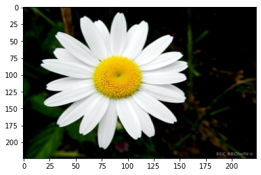

```python
#3E)Predict the image
#From above it can be seen that accuracy is better in CNN
image = cv2.imread('Prediction.jpg')
image = cv2.cvtColor(image, cv2.COLOR_BGR2RGB)
plt.imshow(image,aspect='auto')
plt.show()
```

```python
image_norm=image/255
image_norm=np.reshape(image_norm,(1,224,224,3))
```

```python
#Predicting using CNN model
predict=model_2.predict(image_norm)
```

```python
print('predicted label is ',np.argmax(predict))
```

```
predicted label is  2
```